# Performance Prediction

Smeths

24 August 2016

## Summary

The objective of this assignment is to build a model which predicts “how well” an exercise is being performed. Specifically, whether biceps curls are being performed correctly (classe A in the dataset below) or with a common error (classe B to E).

- B - Throwing elbows to the front
- C - Lifting the dumbbell only half way
- D - Lowering the dumbbell only half way
- E - Throwing hips to the front

Six different people performed the exercise in one of the manners described above with accelerometers and gyroscopes attached to different areas; specifically to their belt, formarm, arm and dumbbell. Readings where taken from these sensors and these reading form the dataset used in this project.

The dataset consists of 19622 reading of 160 different variables. The first 7 variables relate to the time the exercise was performed and who performed it; variables 8 to 45 are relate to accelerometer and gyroscopic reading taken from the belt; variables 46 to 83 relate to accelerometer and gyroscopic reading taken from the arm; variables 84 to 121 relate to accelerometer and gyroscopic reading taken from the dumbbell; variables 122 to 159 relate to accelerometer and gyroscopic reading taken from the forearm and variable 160 is the classe variable.

## Cleaning

As not all of the data in the training set provided is available in the testing set, to clean the data I have removed all of the unavailable and irrelevant variables from the training set. I have also split the training data into a validation and training set, then scaled all of the data according to training set parameters. I have then split the training data into a training set and a validation, so that I can assess the out of sample error before using the model on the testing set.

## Exploratory Analysis

```
##                  freqRatio percentUnique zeroVar   nzv
## pitch_belt        1.046729      13.82473   FALSE FALSE
## yaw_belt          1.042484      14.69939   FALSE FALSE
## roll_arm         50.175000      19.53125   FALSE FALSE
## pitch_arm        87.304348      22.71569   FALSE FALSE
## yaw_arm          29.955224      21.50985   FALSE FALSE
## roll_dumbbell     1.011765      87.63587   FALSE FALSE
## pitch_dumbbell    2.258824      85.53838   FALSE FALSE
## yaw_dumbbell      1.214286      87.14334   FALSE FALSE
## roll_forearm     11.565000      15.09851   FALSE FALSE
## pitch_forearm    62.513514      20.90693   FALSE FALSE
## yaw_forearm      13.933735      14.14742   FALSE FALSE
## magnet_forearm_x  1.127660      12.15183   FALSE FALSE
## magnet_forearm_y  1.129630      15.25985   FALSE FALSE
## magnet_forearm_z  1.000000      13.39164   FALSE FALSE
```

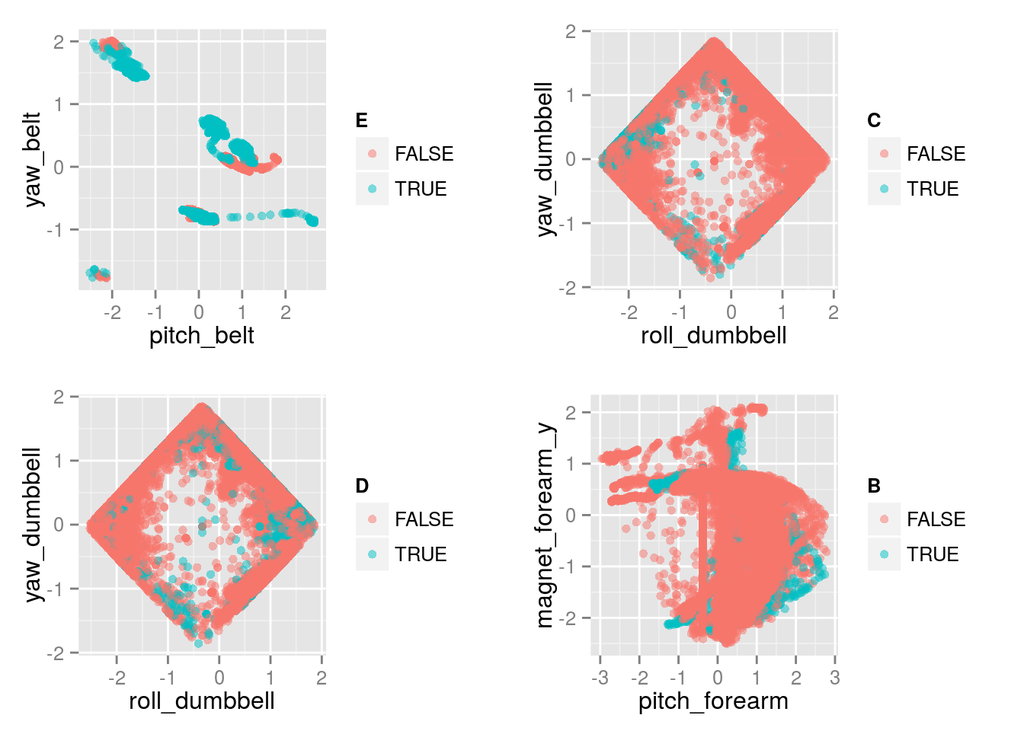

The plot of the belt variables does show some separation, however there is no obvious separation for the rest of the plots.